```python
from sympy import sin, cos, symbols, solve, ln, exp, fourier_series, pi
from sympy.plotting import plot
from sympy.abc import x,t,A
import math
from pprint import pprint
import matplotlib.pyplot as plt
import numpy as np
```

# Tarea 2 - Ignacio Palos Reynoso

## 1. Encuentre la serie de Fourier para la función $f(t)$ definida por $f(t) = t^2$ en el intervalo $(−\pi, \pi), f(t + 2\pi) = f(t)$.

```python
s1= fourier_series(t**2,(t,-pi,pi))
s1
```

$\displaystyle - 4 \cos{\left(t \right)} + \cos{\left(2 t \right)} + \frac{\pi^{2}}{3} + \ldots$

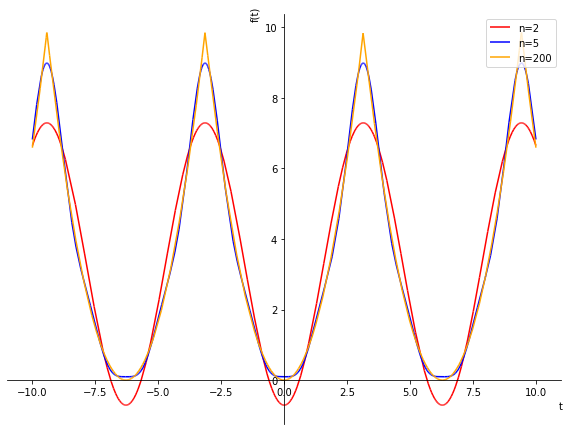

```python
s10 = plot(s1.truncate(n=2),show=False, line_color='red', label='n=2',size=(8,6), legend=True)
s50 = plot(s1.truncate(n=5), show=False,line_color='blue', label='n=5')
s200 = plot(s1.truncate(n=200), show=False, line_color='orange', label='n=200')
s10.append(s50[0])
s10.append(s200[0])
s10.show()
```

## 2. Encuentre la serie de Fourier compleja de la función periódica sinusoide rectificada f (t) definida por:

\begin{align} f(t) = Asin(\pi t) \quad ; \quad t\in (0,1) \\[10pt] f(t+T) = f(t) \quad ; \quad T=1 \end{align}

```python
s2 = fourier_series(sin(pi*t),(t,0,1))
```

## La serie compleja de $Asin(\pi t) \quad ; \quad t\in(0,1)$ es:

\begin{align} \boxed{\large{\frac{2}{\pi} - \frac{2A}{\pi} \sum_{n=2}^\infty \frac{e^{in\pi t}+e^{-in\pi t}}{(n-1)(n+1)}}} \end{align}

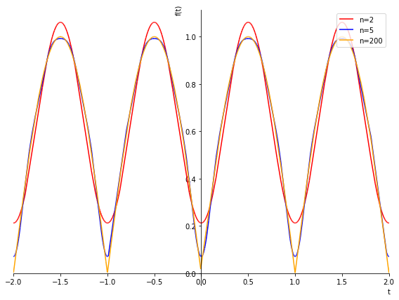

```python
s10 = plot(s2.truncate(n=2),show=False, line_color='red', label='n=2',size=(8,6), legend=True,xlim=(-2,2))
s50 = plot(s2.truncate(n=5), show=False,line_color='blue', label='n=5')
s200 = plot(s2.truncate(n=200), show=False, line_color='orange', label='n=200')
s10.append(s50[0])
s10.append(s200[0])
s10.show()
```

## 3. Demuestre que las series de Taylor de las funciones $sin(x)$, $cos(x)$ y $e^x$ son respectivamente:

\begin{align} sin(x) &= \sum_{n=0}^\infty \frac{(-1)^n}{(2n+1)!}x^{2n+1} \\[10pt] cos(x) &= \sum_{n=0}^\infty \frac{(-1)^n}{(2n)!}x^{2n} \\[10pt] e(x) &= \sum_{n=0}^\infty \frac{(x)^n}{(n!)}\\[10pt] \end{align}

## Solución:

Tenemos que la serie de Taylor se define como:

\begin{align} \sum_{n=0}^\infty \frac{f^{(n)}(a)}{n!}(x-a)^n \end{align}

entonces tenemos que: \begin{align} sin'(x) &= cos(x) \\ cos'(x) &= -sin(X) \\ e'(x) &= e(x) \\ \end{align}

por lo tanto, si a=0 \begin{align*} sin(x) &= sin(0) + \frac{cos(0)}{1!}x - \frac{sin(0)}{2!}x^2 -\frac{cos(0)}{3!}x^3 + ... \\[10pt] {}&= 0 + x + 0 - \frac{x^3}{3!} - 0 + \frac{x^5}{5!} + 0 - \frac{x^7}{7!} - ... \\[10pt] \large{\color{blue}{sin(x) = \sum_{n=0}^\infty \frac{(-1)^n}{(2n+1)!}x^{2n+1}}} \end{align*}

análogamente tenemos que:

\begin{align} cos(x) &= cos(0) - \frac{sin(0)}{1!}x - \frac{cos(0)}{2!}x^2 + \frac{sin(0)}{3!}x^3 - ... \\[10pt] {} &= 1 - \frac{x^2}{2!} +\frac{x^4}{4!} - \frac{x^6}{6!} + \frac{x^8}{8!} - ... \\[10pt] \large{\color{blue}{cos(x) = \sum_{n=0}^\infty \frac{(-1)^n}{(2n)!}x^{2n}}} \end{align}

y finalmente:

\begin{align*} e(x) &= e(0) + \frac{e(0)}{1!}x + \frac{e(0)}{2!}x^2 + \frac{e(0)}{3!}x^3 ... \\[10pt] {}&= \frac{x}{1!} +\frac{x ^2}{2!} + \frac{x^3}{3!} + \frac{x^4}{4!} + ... \\[10pt] \large{\color{blue}{e(x) = \sum_{n=0}^\infty \frac{(x)^n}{(n!)}\\[10pt]}} \end{align*}